# Informe Primer Semestre 2021

Educación Musical

Claudio Rojas. Director Académico

2021-07-31

## 0.1 Presentación

El presente informe tiene como objetivo revisar el trabajo del sector, a través de información que sistematiza los resultados académicos del I semestre y recoge lo proyectado para el II semestre del presente año, considerando las definiciones claves que tenemos como colegio pero también como una institución de la Compañía de Jesús.

Este informe incluye:

- Definiciones Clases
- Informe de Notas
- Metas de Aprendizaje.
- Propuestas de Evaluación II Semestre.

Cada una de las partes de informe incluye sugerencias que bucan orientar la reflexión y práctica del sector para poder realizar los ajustes que sean necesarios para el trabajo de la segunda parte del presente año.

## 0.2 Definiciones Claves

Les recuerdo tener presente las definiciones claves tanto a nivel de red ignaciana como interna que deben siempre orientar nuestro trabajo académico.

### 0.2.1 Envío 3 Planificación Estratégica de los colegios Jesuitas

Asegurar que los 10 colegios y escuelas jesuitas desarrollen las prácticas y procesos necesarios para ofrecer la excelencia académica propia de una comprensión ignaciana de la educación de calidad.

### 0.2.2 Nuestra Definición de Calidad

Nosotros, como comunidad sanjavierina, entendemos por educación de calidad todo aprendizaje que nos lleva a descubrir y desarrollar nuestras capacidades de manera integral, formándonos como personas competentes, conscientes, comprometidas, compasivas y creativas, para así conocer y amar más y mejor a Jesucristo, sirviendo a nuestros hermanos en los diversos contextos sociales.

### 0.2.3 Nuestro Foco de Mejora

Fortalecer la propuesta curricular, con una didáctica renovada, bajo el Paradigma Pedagógico Ignaciano.

## 0.3 Informe de Notas

El informe de notas contiene la siguiente información:

- Tabla de Resumen de las notas por nivel.
- Notas de 1º básico a IVº medio.
- Distribución por Niveles de Logro.

En el caso de los resultados, les sugiero revisar:

- Los promedios finales obtenidos en cada nivel por parte de la asignatura.
- Cantidad de estudiantes que están en cada nivel de logro.
- Las diferencias de resultados entre hombres y mujeres.

### 0.3.1 Tabla de Resumen de Notas:

La tabla incluye la información de la asignatura por nivel:

- Promedio de la asignatura.
- Nota Mínima.
- Mediana.
- Nota Máxima.

#### 0.3.1.1 Tabla

En el caso de las notas de Iº y IIº Medio (9 y 10) corresponden a las notas de Artes y Música conjuntamente.

[output not shown]

### 0.3.2 Notas de Artes Musicales

En este caso, las notas de de Iº y IIº Medio (9 y 10) corresponden a las notas de Artes y Música conjuntamente.

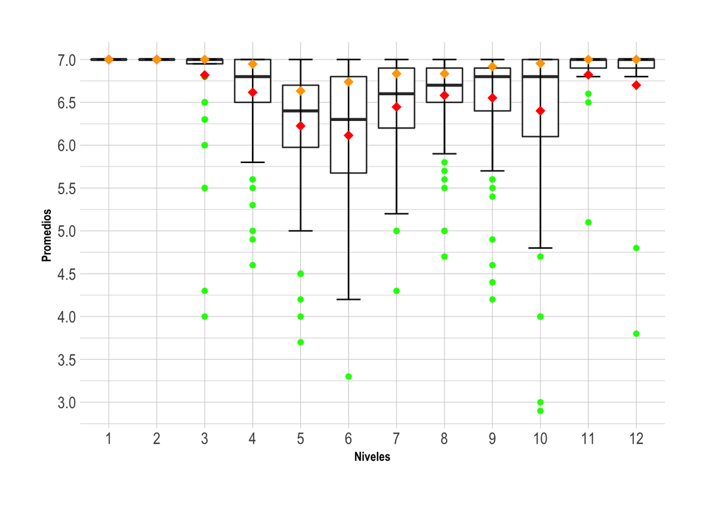

### 0.3.3 Distribución de Estudiantes por Niveles de Logro y diferenciado por Sexo.

#### 0.3.3.1 Primeros Básicos

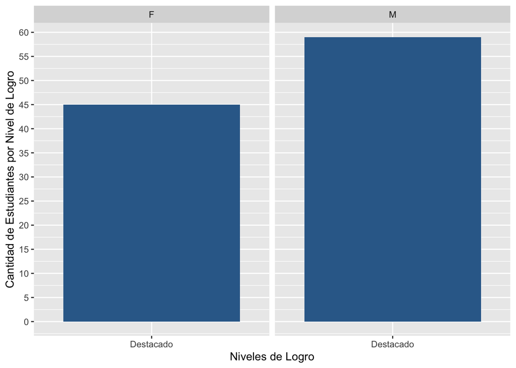

#### 0.3.3.2 Segundos Básicos

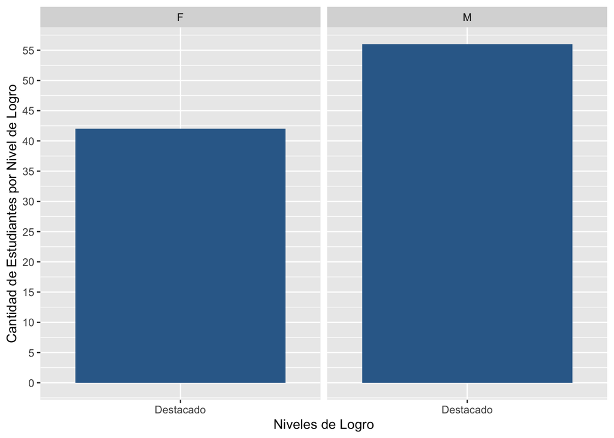

#### 0.3.3.3 Terceros Básicos

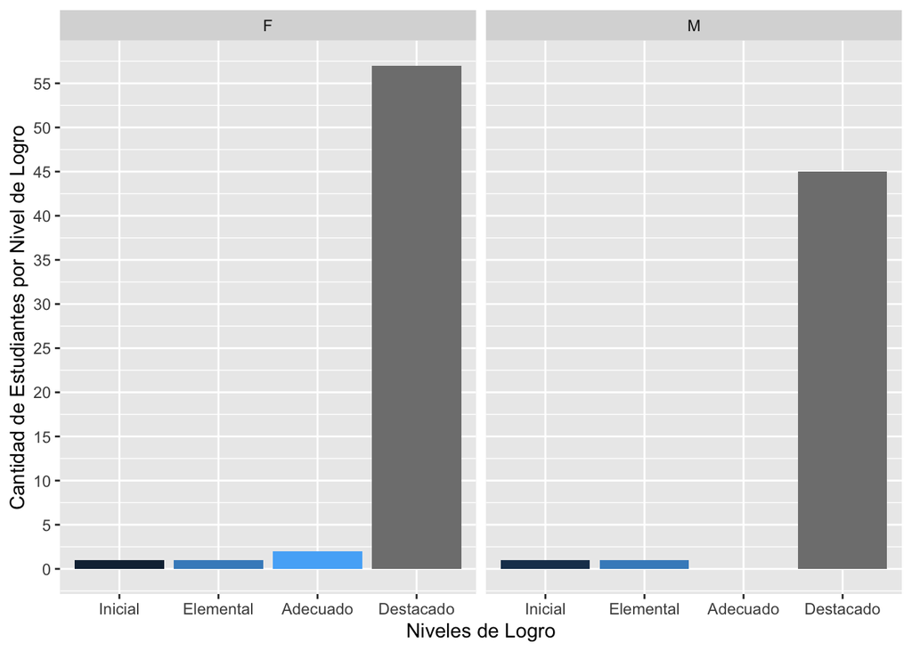

#### 0.3.3.4 Cuartos Básicos

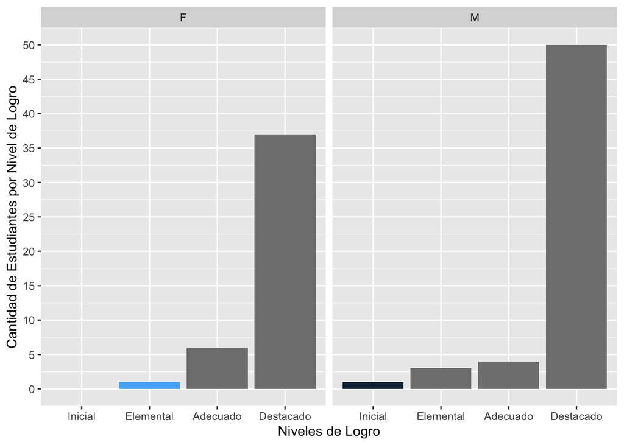

#### 0.3.3.5 Quintos Básicos

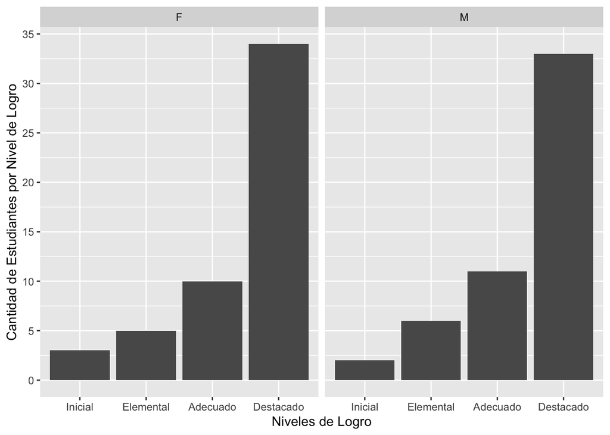

#### 0.3.3.6 Sextos Básicos

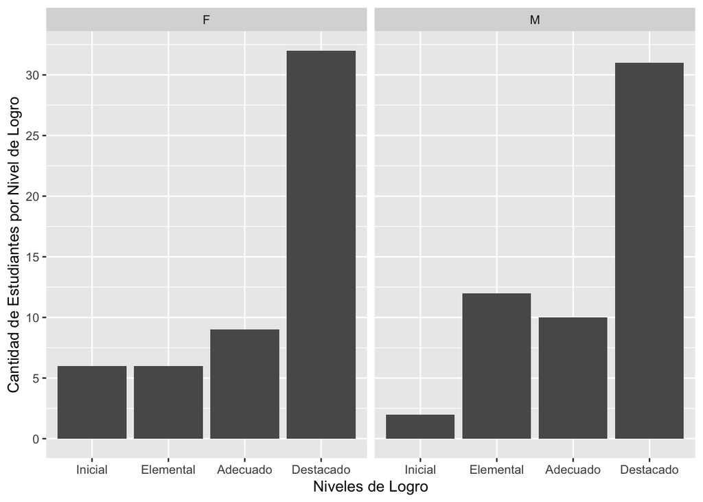

#### 0.3.3.7 Séptimos Básicos

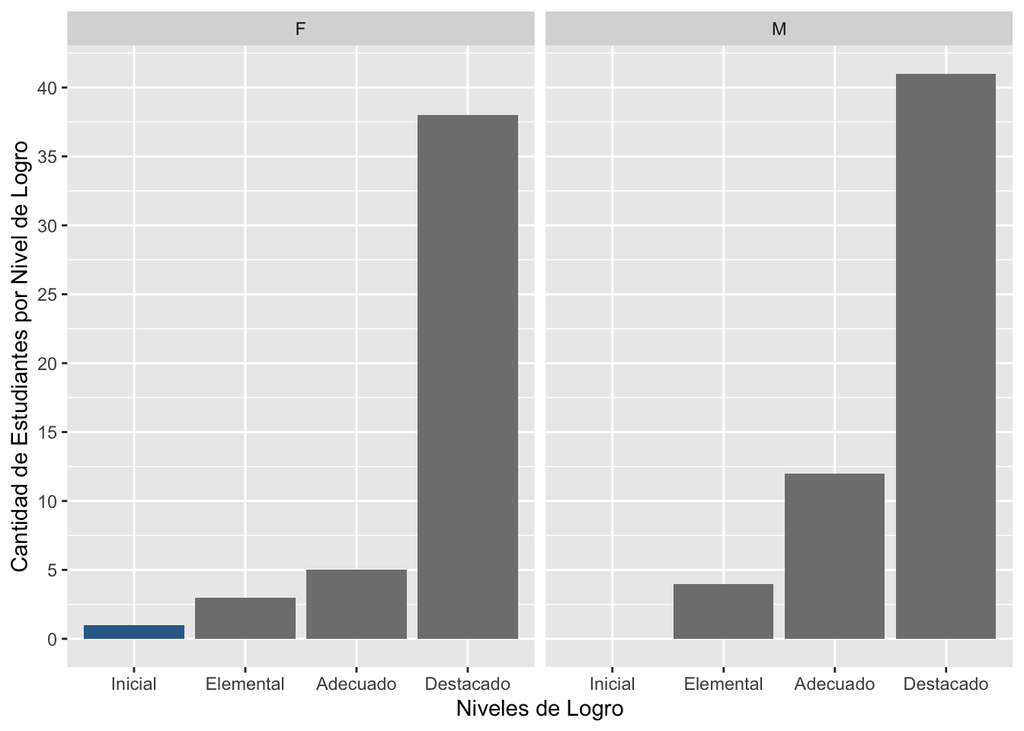

#### 0.3.3.8 Octavos Básicos

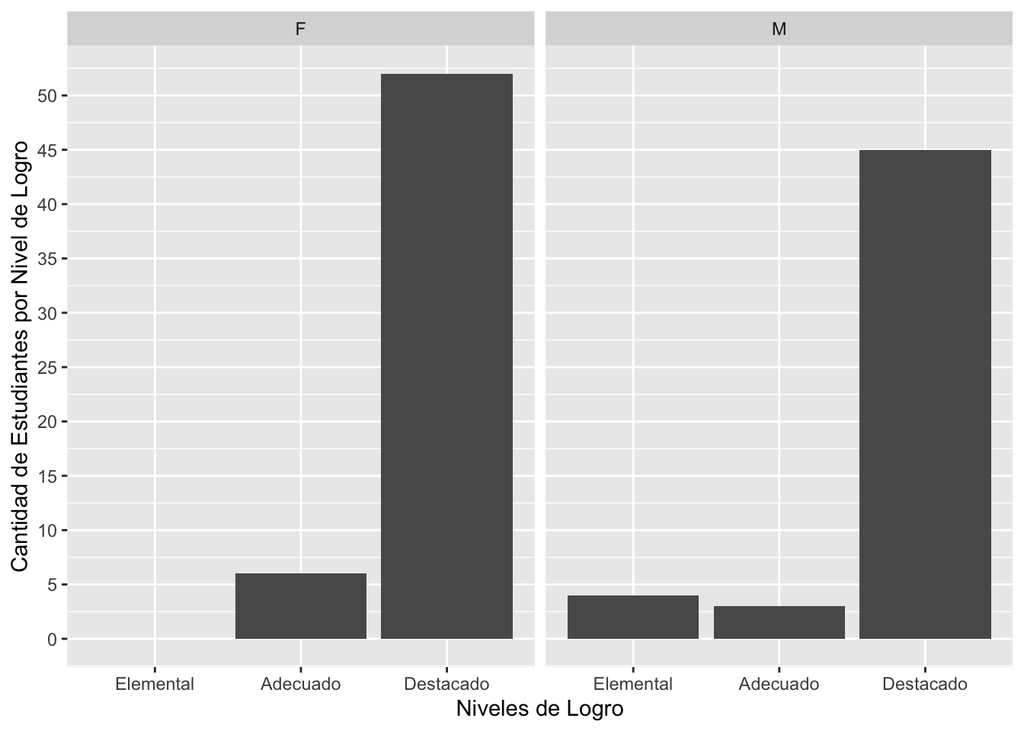

#### 0.3.3.9 Primeros Medios Artes Musicales y Artes Visuales

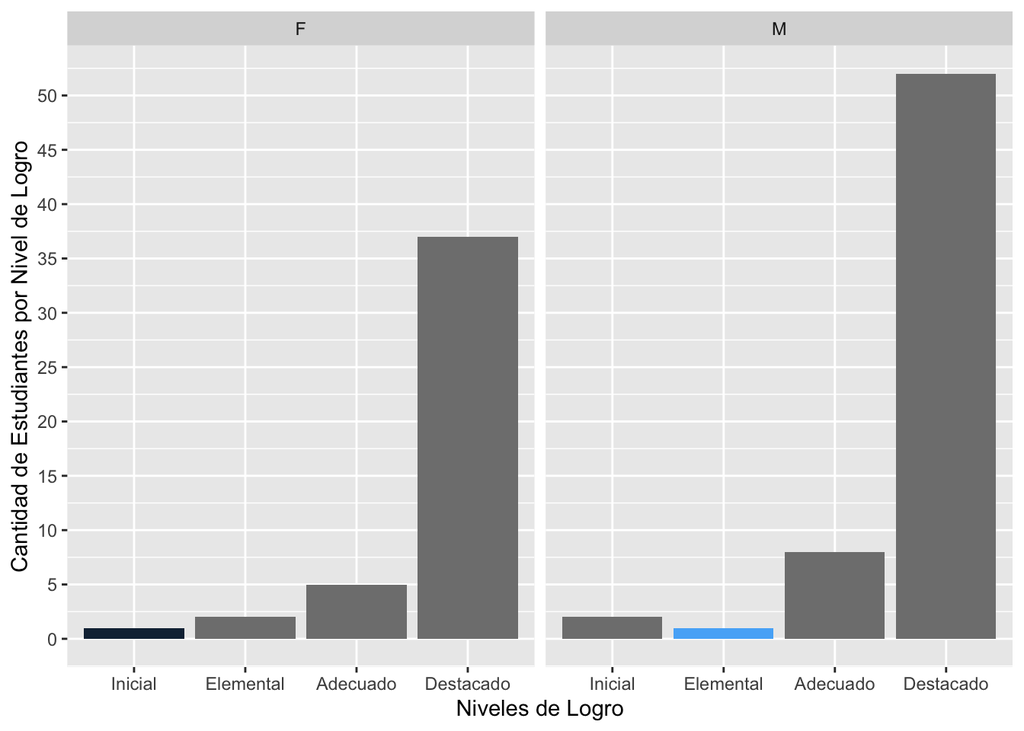

#### 0.3.3.10 Segundos Medios Artes Musicales y Artes Visuales

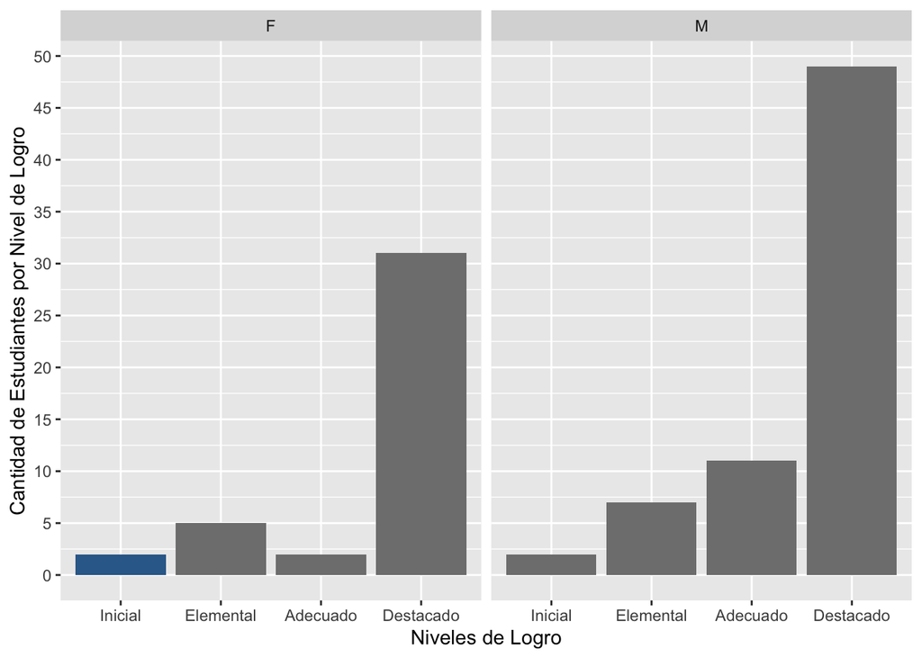

#### 0.3.3.11 Terceros y Cuartos Medios

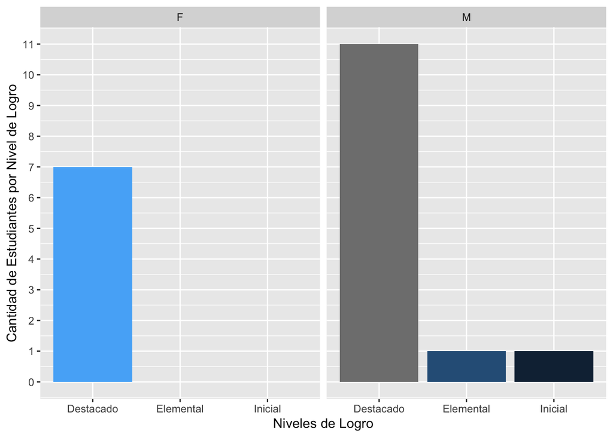

## 0.4 Metas de Aprendizajes

Se presentan las metas declaradas por el sector desde 1º básico a IIº medio (al 15 de julio). Ajustar las metas considerando los siguientes criterios:

- **¿Contienen errores gramaticales:** **Redacción, Faltas de Ortografía** **?**
- **¿Están escritas de manera clara y precisa?, ¿Se usan los verbos adecuados?:**

Ejemplo 1: *“Conocer, distinguir e identificar figuras ritmicas simples y su simbologìa musical, desarrollados en el contexto de Villancicos de Navidad.”* **Priorizar verbos que engloben más que una secuencia de éstos y que sean verbos que se puedan medir con claridad. Corregir este tipo de metas.**

Ejemplo 2: *“Arreglos simples incorporando nuevos elementos musicales, desarrollados en el contexto de Mùsica de Pueblos Originarios.”* **Esto no es una meta es una actividad que podría evaluar una meta.Corregir este tipo de metas.**

Ejemplo 3: *“Lectura y práctica musical de la escala de Do mayor en base a repertorio de música universal, haciendo música de manera individual y grupal, manejando conceptos del lenguaje musical.Lograr que los estudiantes puedan desarrollar una lectura ritmica( utilizando figuras sencillas como blancas y negras) y de notas musicales con colores..”* **En este caso, la lectura es una actividad y el desarrollar la lectura ritmica sería la meta.**

Ejemplo 4: *"Interpretan obras musicales en que el trabajo técnico permite comprender claramente el propósito expresivo de la obra. Interpretan obras, aplicando recursos técnicos y musicales de acuerdo al propósito expresivo.* **En este caso, se deben fusionar en una meta que las englobe.**

- **Ajustar las metas que contengan verbos que son poco precisos a la hora de medir:** *Comprender, Reflexionar*. **Pero también, aquellas que contengan verbos que den cuenta de niveles básicos de aprendizaje:** *Identificar, Reconocer*. **Las metas de aprendizajes deben ser** *Medibles* **pero también** *Desafiantes*.
- **Precisar si en algunos niveles habrá una sola meta para el semestre:** Ejemplo: *4ºbásico*

### 0.4.1 Metas de Aprendizajes Primer Ciclo

| Nivel | Segunda Unidad | Tercera Unidad |
| --- | --- | --- |
| Primero Básico | Conocer, distinguir e identificar figuras ritmicas simples y su simbologìa musical, desarrollados en el contexto de rondas infantiles y folklor. Pràctica instrumental a partir del uso del metalòfono. | Conocer, distinguir e identificar figuras ritmicas simples y su simbologìa musical, desarrollados en el contexto de la Navidad. Pràctica instrumental a partir del uso del metalófono. |
| Segundo básico | Arreglos simples incorporando nuevos elementos musicales, desarrollados en el contexto de Mùsica de Pueblos Originarios. | Conocer, distinguir e identificar figuras ritmicas simples y su simbologìa musical, desarrollados en el contexto de Villancicos de Navidad. |

### 0.4.2 Metas de Aprendizajes Segundo Ciclo

| Nivel | Segunda Unidad | Tercera Unidad |
| --- | --- | --- |
| Tercero básico | Identificar las notas en el pentagrama asociando las figuras rìtmicas aprendidas en el contexto de mùsica de pelìculas y series infantiles. Practica Instrumental a partir del uso de metalófonos, piano… | Arreglos musicales simples incorporando nuevos instrumentos, desarrollados en el contexto de mùsica latinoamericana y villancicos de navidad. Práctica instrumental apoyados en el uso de metalófonos, p… |
| Cuarto básico | Lectura y práctica musical de la escala de Do mayor en base a repertorio de música universal, haciendo música de manera individual y grupal, manejando conceptos del lenguaje musical. Lograr que los es… |  |
| Quinto básico | Lectura y práctica musical de la escala de Do mayor y Sol mayor en base a repertorio de música universal, ampliando el panorama de la música, tanto de América como del mundo, de diferentes géneros y e… |  |
| Sexto básico | Lectura y práctica musical de la escala de Do mayor, Sol mayor y Fa mayor, a través de la interpretación musical, los estudiantes van fortaleciendo habilidades comunicativas para ser capaces de compar… |  |

| Nivel | Segunda Unidad | Tercera Unidad |
| --- | --- | --- |
| Séptimo básico | Prestan atención al quehacer musical propio y de otros. Cantan y tocan a más de una voz comprendiendo aspectos rítmicos y melódicos. Lograr que los estudiantes puedan interpretar el repertorio según s… | Tocan instrumentos musicales con precisión rítmica y melódica, demostrando una actitud de confianza y seguridad. Participan de actividades musicales con interés y dedicación, siguiendo las indicacione… |
| Octavo básico | Cantan/tocan repertorio diverso aplicando las habilidades y los conocimientos desarrollados. Cantan/tocan música popular aplicando rasgos estilísticos simples. Lograr que los estudiantes puedan interp… |  |
| Primero medio | Demuestran fluidez en la interpretación musical de repertorio diverso a una y más voces. Aplican características de algún estilo al cantar y tocar repertorio diverso (folclor, popular, entre otros), d… | Transmiten un propósito expresivo utilizando elementos del lenguaje musical al cantar y tocar, de acuerdo al repertorio interpretado. Evalúan propositivamente el desempeño musical propio y de sus comp… |
| Segundo medio | Cantar y tocar repertorio diverso sobre la base de una selección personal, desarrollando habilidades tales como manejo de estilo, fluidez, capacidad de proponer y dirigir, identificación de voces y fu… | Conocer y comprender cómo la música se ha ligado naturalmente con otras artes en distintas épocas y lugares |

## 0.5 Plan de Evaluación IIº semestre 2021

En la siguiente tabla se presentan los procedimientos e instrumentos declarados por el sector (1º básico en adelante) y la cantidad de veces que se repiten. Revisar lo declarado en el plan de evaluación considerando los siguientes criterios:

- ¿Hay claridad en el sector entre lo que es un procedimiento y su diferencia con el instrumento? **En el caso de dudas, revisar nuestro [Reglamento de Evaluación](https://www.colsanjavier.cl/files/documentos/REGLAMENTO%20INTERNO%20DE%20EVALUACIÓN%202021.%20%5Bv.%2030-04-2021%5D.pdf).**
- ¿Existe una diversidad de formas de evaluar o se limitan a la práctica recurrente de procedimientos e instrumentos utilizados en el sector? **¿Por qué se declaran realizar tantas pruebas?**

Por último, se agrega una nube de palabras que quiere reflejar la diversidad de instrumentos y el peso de cada uno de ellos.

|  | word | freq |
| --- | --- | --- |
| prueba | prueba | 18 |
| instrumental | instrumental | 9 |
| interpretacion | interpretacion | 9 |

[interactive chart not shown]

En el caso del **Plan de Nivel**, les solicito que como sector concuerden y plasmen en la planificación

- En qué sesiones se evaluarán el OA que se hace responsable el sector.
- El instrumento que usarán para concretar esta evaluación.

Es importante que ustedes como jefes de sector hagan sequimiento de este proceso, ya que es el medio con el cual concretamos la formación integral. Pero, además, los resultados obtenidos, es lo que informamos a los estudiantes y sus familias en los distintos objetivos de aprendizajes asociados a las tres dimensiones de nuestro Mapa de Formación Integral.

## 0.6 Planificación de Clases

Durante las siguientes dos semanas pondremos énfasis en la planificación. Por lo que es importante avanzar toda la unidad 2 durante este tiempo. Para organizar la planificación les sugiero pensar un modelo de clases que considere la siguiente estructura. Esto con el objetivo de asegurar el aprendizaje de sus estudiantes:

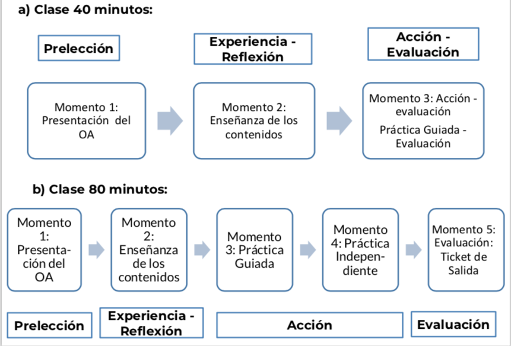